# Electronic word-of-mouth and the brand image_ Exploring the moderating role of involvement through a consumer expectations lens

Converted from PDF `Krishnamurthy-ElectronicWOMBrandImage-2018-JRCS.pdf` · 8 pages · anchors: page `#pN`, block `#pN-bK`

Page 1

Contents lists available at ScienceDirect

## Journal of Retailing and Consumer Services

journal homepage: www.elsevier.com/locate/jretconser

### Electronic word-of-mouth and the brand image: Exploring the moderating role of involvement through a consumer expectations lens

### Anup Krishnamurthy<sup>a</sup><sup>,</sup><sup>⁎</sup>, S. Ramesh Kumar<sup>b</sup>

a St. Joseph's Institute of Management, 28/1 Primrose Road, Bangalore 560025, India b Indian Institute of Management Bangalore, Bannerghatta Road, Bangalore 560076, India

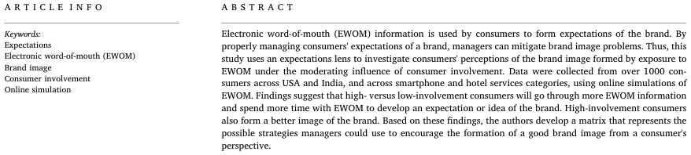

NOTE: complex table shown as an image of the PDF; the text below is a rough machine extraction and may be mis-aligned.

**extracted text (unreliable layout)**

1. Introduction

Electronic word-of-mouth (EWOM), including online ratings and reviews, informs consumers about the functional and symbolic aspects of a brand (Hu et al., 2012; Krishnamurthy and Kumar, 2015). Consumers process such brand information to form an image of the brand (Gensler et al., 2015; Meenaghan, 1995). EWOM information also helps consumers form expectations of a brand prior to purchase because EWOM information reduces uncertainty in decision-making processes for consumers (Krishnamurthy and Kumar, 2015). In turn, these expectations influence consumers’ perception of the brand image (Chen, 2010; Lamons, 2003). Therefore, in this study, we examine how consumers use EWOM to form expectations, and thereby understand the impact of EWOM on consumers' perception of the brand image.

The influence of EWOM has been steadily increasing, especially due to the proliferation of social media. EWOM accounts for almost 25% of the search results for the world's top brands (AdWeek, 2015). This influence of EWOM on consumers throughout the consumer decision journey is most striking for developing markets like India (Bughin et al., 2010). It is in this crucial context that we conduct our study. Consider the example of one of Nestle's flagship brands, Maggi, when it faced a crisis with its instant noodles product in 2015 in India. A local government food testing laboratory had reported that Maggi's noodles contained lead far beyond permissible limits. Negative EWOM

spread quickly about the brand, which affected its image adversely (Datta, 2018; Sultana, 2017). Consumers also started to have low expectations of the brand because of the slow response from management to all the negative EWOM (Sultana, 2017). This resulted in reduced purchases and further erosion of the brand image. Perhaps, Nestle India's half a billion dollar loss during this crisis could have been mitigated if management was cognizant of the impact EWOM can have on brand expectations and thereby on the brand image as well.

So far, research on the topic of EWOM's impact on the consumers' perception of the brand image has been scant (Chiou and Cheng, 2003; Reza Jalilvand and Samiei, 2012; Wu and Wang, 2011). We attempt to add to this body of knowledge by examining how consumers use EWOM to form expectations and thereby develop their image of the brand. Since a consumer's motivation to gather and process information about a brand is often conceptualized in terms of consumer involvement (e.g., Bloch and Richins, 1983; Celsi and Olson, 1988; Gabler and Reynolds, 2013; Greenwald and Leavitt, 1984; Jun and Vogt, 2013), the moderating influence of the consumer's level of involvement was included in our study. We believe that such knowledge will not only contribute to literature, but is also likely to benefit those delegated with the responsibility to reduce the incongruity between the projected brand image and consumers' own expectations of the brand.

The rest of this article is structured as follows. First, we discuss the constructs of interest and develop the hypotheses. Next, the

https://doi.org/10.1016/j.jretconser.2018.03.010 Received 5 October 2017; Received in revised form 8 February 2018; Accepted 14 March 2018

⁎ Corresponding author.

E-mail addresses: anup@sjim.edu.in (A. Krishnamurthy), rkumar@iimb.ac.in (S.R. Kumar).

Journal of Retailing and Consumer Services 43 (2018) 149–156

Available online 30 March 2018 0969-6989/ © 2018 Elsevier Ltd. All rights reserved.

T

Page 2

methodology is presented, explaining the data collection through online simulations. Finally, we present the results and conclude with a discussion on the implications of this work.

2. Background

2.1. Electronic word-of-mouth (EWOM)

Word-of-mouth has been defined as “informal communications directed at other consumers about the ownership, usage, or characteristics of particular goods and services and/or their sellers” (Westbrook, 1987, p.261; Litvin et al., 2008; Sirakaya-Turk et al., 2015). More recently, the internet has dramatically changed the way we communicate, transforming word-of-mouth communications, into electronic word-ofmouth (EWOM). While the primary difference between offline word-ofmouth and EWOM is that EWOM is transmitted through internet-based technology, in all other aspects, EWOM is very similar to offline wordof-mouth (Litvin et al., 2008). For example, Godes and Mayzlin (2004) found that online conversations are a proxy for offline ones; Reichelt et al. (2014) confirmed that the credibility of information is just as important for EWOM as it is for offline word-of-mouth; Riegner (2007) found that 50% of all recent purchases of internet users were influenced by some online source of information, of which EWOM was the most influential; Riegner (2007) also found that internet users spent 27% of their time online in communication activities, and of those who created content online, 31% had spread EWOM about a product.

EWOM is increasingly becoming the focus of word-of-mouth research today due to its wide-reaching impact. For example, researchers have found that EWOM is positively associated with a firm's stock return (Xun and Guo, 2017), has the potential to dilute consumer-based brand equity (Bambauer-Sachse and Mangold, 2011), and plays a crucial role in the diffusion of new products (Plotkina and Munzel, 2016). EWOM is also not limited to any particular technology platform (see Thakur, 2018) or to any particular consumer demography – researchers have found that even teenagers are major generators and consumers of EWOM (Mishra et al., 2017).

Consumers use several different sources of information to form their image of a brand (Dobni and Zinkhan, 1990a, 1990b). This is partly why prior to making purchases, consumers often undertake an information search (Urbany et al., 1989) – such information not only helps consumers to make a purchase decision, but also helps them to develop their interpretation of the brand image. Consumers actively collect and integrate information from both internal and external sources (Schmidt and Spreng, 1996). The internal sources refer to what is stored and retrieved from the consumer's memory, while all other sources, including EWOM, fall into the external category (Oliver, 2011). EWOM is therefore one of those many pieces of information used by consumers to form their idea of the brand image. Thus, understanding the impact of EWOM assumes importance in research today, especially since consumers use this information to develop their image of the brand (Gensler et al., 2015; Meenaghan, 1995).

At the same time, as consumers peruse EWOM information, they reduce uncertainty in their decision-making processes and thereby develop expectations of the brand (Krishnamurthy and Kumar, 2015). These brand expectations also play a role in determining consumers’ image of a brand, as described in the next section. Therefore, by properly managing brand expectations, managers have a chance to reduce the incongruity between the firm's projected brand image and consumers' perceptions of the brand image (Haynes et al., 1999; Hu et al., 2012; Keller, 1993). In other words, EWOM has an influence on the brand image through the brand expectations formed by the consumer. Thus, understanding how EWOM helps to form brand expectations can aid in endeavors directed towards improving the consumer's image of the brand.

2.2. Brand expectations

An expectation is the concept that individuals tend to learn the consequences of their actions, and therefore expect certain outcomes to follow particular actions (Oliver, 1980; Olson and Dover, 1979; Tyron, 1994). This idea is often extended to others, including brands (Gupta and Stewart, 1996). For example, people expect a brand that advertises its corporate social responsibility to be indeed socially responsible, and any actions that violate these brand expectations can erode the brand's image (Becker-Olsen et al., 2006; Werther and Chandler, 2005).

Brand expectations play an important role in the formation of various brand elements, including the brand image. The formation of a favorable brand image is often dependent on the positive disconfirmation of consumers’ brand expectations (e.g., Dioko et al., 2010; D'Hauteville et al., 2007). In their foundational analysis of the brand image, Dobni and Zinkhan (1990) state that brand expectations are one of the triggers by which brand images are activated. Consequently, the inconsistency between a firm's projected brand image and consumers' image of a brand can be reduced by managing consumers' expectations of a brand (Haynes et al., 1999; Hu et al., 2012; Keller, 1993).

The common underlying theme behind brand expectations is that they are formed using information available to the consumer (e.g., Dawar and Pillutla, 2000). This study focuses on one such source of information that has today become almost ubiquitous, namely, EWOM (like customer reviews and comments, social-media based rankings, and so on).

While consumers might seek out EWOM information about a brand in order to form an expectation of the brand, not all product categories are equally involving for all consumers. For example, although consumers might search for EWOM information about both refrigerators and wireless mobile chargers, it likely that most consumers will be more involved in the former than the latter. Sometimes consumers are simply more involved due to their intrinsic interest in a product category (Mittal and Lee, 1989). Therefore, the level of consumers’ involvement also needs to be considered when attempting to understand how consumers use EWOM information to form expectations about a brand.

2.3. The moderating role of consumer involvement

In existing literature, a consistent finding is that the more involved people are in something, the more motivated they become to complete their task or achieve their goal (e.g., Dholakia, 2001; Gabbott and Hogg, 1999; Maclnnis and Jaworski, 1989). The Elaboration Likelihood Model serves as the mechanism behind why different levels of involvement result in varying degrees of extensiveness in information processing (Herold et al., 2016; Petty and Cacioppo, 1981). When a consumer is highly involved in a product category, there is a greater likelihood that they will carefully evaluate merits and weaknesses, that is, they will be elaborate in their information gathering and processing (Petty et al., 1983; Petty and Cacioppo, 1984). As consumer involvement increases, so does the personal relevance of the brand to the consumer (Zaichkowsky, 1985). This results in a greater willingness to apply more cognitive resources to processing information (Petty et al., 1983). Therefore, it is likely that the more involved the consumer is in the product category, the greater their likelihood of elaboration and willingness to process information to form an expectation about the brand. In the context of this study, such elaboration would include going through more EWOM information and spending more time with such information before forming brand expectations.

H1a. : When forming brand expectations, high-involvement consumers will use more EWOM information than low-involvement consumers.

H1b. : High-involvement consumers will spend more time with EWOM information before forming brand expectations than low-involvement consumers.

A. Krishnamurthy, S.R. Kumar *Journal of Retailing and Consumer Services 43 (2018) 149–156*

150

Page 3

Previous research has found that higher involvement is associated with more favorable attitudes towards a brand (Langaro et al., 2015; Park and Young, 1986; MacKenzie and Spreng, 1992). Such an association exists because the higher the consumer's involvement with a product category, the more personally relevant that category is to the consumer (MacKenzie and Spreng, 1992); and by increasing personal relevance, high involvement product categories form associations with the consumer's self-image or its expression (e.g., Bloch, 1982). On similar lines, when forming brand expectations using EWOM information, it is therefore likely that high-involvement consumers will form higher (i.e., more favorable) expectations than low-involvement consumers.

H2. : High-involvement consumers will form higher brand expectations than low-involvement consumers when using EWOM information to form expectations.

3. Methodology

The responses were collected through an online simulation of EWOM (see the Procedure section for details). Respondents were randomly assigned to one of two simulations. Due to the inherent differences between product and services, we chose one product and one service category for our simulations in order to make our findings more generalizable. The simulations focused on either a product (smartphones) or a service (hotel services). For this research, smartphones and hotel services were chosen as they are widely purchased online by consumers. This provided two benefits. Firstly, these categories would make the simulation more realistic because the simulation was conducted over the internet, which is most consumers’ natural context for the purchase of these products. Secondly, using these categories would help lower the number of responses rejected because of a lack of awareness. All brand-identifying information was removed so that only EWOM information, and not prior brand experience, would influence the behavior of respondents in the simulation.

Following recent studies, the responses were collected through the Amazon's Mechanical Turk platform (e.g., Erat and Bhaskaran, 2012; Ghose et al., 2012; Loewenstein et al., 2011). An Internet Protocol (IP) address filter was used to prevent duplicate responses. We had respondents from the United States and India to increase the generalizability of our findings. In both countries, the survey was administered in English to avoid the problems of validity across different languages (Douglas and Craig, 2006).

One of the requirements of this study was to determine the various types of EWOM to include in our simulations. This is because it was essential that these types of EWOM were indeed the types of EWOM that consumers are likely to find while browsing a website. To determine which these types of EWOM are, we collected the top 100 websites in terms of web-traffic in USA and India. Following past research (Karpf, 2012), the list of top websites were taken from the rankings by Alexa, Quantcast, comScore, and Hitwise. We consolidated this data into a single list, which, after removing duplicate websites, consisted of 286 unique websites. Thereafter, we visited each website to document the different types of EWOM available. This task uncovered 14 ways in which EWOM was displayed on websites (see Appendix). For the purpose of this study, we chose only those types of EWOM that were present in at least 25% of the websites that allowed purchases. There were nine such types of EWOM.

3.1. Sample

Across both countries, we collected 1142 responses (see Table 1 for details). The average experience respondents had with mobile phones was 9.5 and 8.3 years in USA and India respectively, and vacationing once a year was equally common to both Americans (41%) and Indians (45%). Further, a majority of the respondents in both USA (88%) and

India (56%) reported that they booked hotels for vacations online rather than through any other method. Respondents’ satisfaction with their current phone was rated 5.5 (USA) and 5.7 (India) on average, while satisfaction with their last holiday was rated 5.5 (USA) and 5.7 (India) on average, with both scales ranging from 1 to 7 (seven being most satisfied).

3.2. Measures

During the simulations, the online software kept track of each respondent's behavior including which pieces of EWOM information were accessed and the time spent in forming expectations. Two pretests were conducted (N1 = 53, only from India and only MBA students; N2 = 99, from India and USA). Using the results of the pretests, minor changes were made to the online program code and the wording of the final simulations.

3.2.1. Brand expectations The favorableness of the respondent's brand expectations was measured using three items. Over the years, researchers have proposed numerous types of expectations (e.g., Prakash, 1984; Swan et al., 1980; Van Raaij, 1998). However, most often, consumer needs and expectations “overlap exactly, becoming interchangeable” (Oliver, 2011, p. 64). Thus, the well-known typology of consumer needs – functional, symbolic and experiential (Park et al., 1986) – is frequently used as the types of expectations that consumers form about a brand. Based on the definitions of functional, symbolic and experiential expectations (Park et al., 1986), a single-item was developed for each. Together, these three items formed the scale for measuring the level of expectations. The Cronbach alpha for this scale was .78 in both simulations, both values being above the prescribed threshold of .70 (Hair et al., 2006; Nunnally, 1978). The purpose of this scale was to measure the favorableness of consumers’ expectation rather than determining which expectation the consumer has formed. That is why we allowed for different types of expectations so that we could get a clearer picture of the level of expectations (high vs. low) formed by the respondent. As an alternative measurement, a single-item measure was also used to determine the respondent's overall expectations. This item was measured on a six-point semantic differential scale. The correlation between this overall measure and the three item scale for expectations was .71 (p < .01) in the smartphone simulation and .62 (p < .01) in the hotel services simulation. The respondent also had the choice to choose an “I am not sure” option in case they were unable to form an expectation from the available information.

3.2.2. Degree of involvement Zaichkowsky (1994) Product Involvement Inventory is used most often as the method to measure a consumer's degree of involvement (e.g., Freling and Forbes, 2013; Myers et al., 2013). Therefore, we used this ten-item scale to measure a consumer's degree of involvement. A median split of the involvement score was used to classify consumers into high- or low-involvement types. Cronbach alpha was .93 in both simulations.

We tested for measurement equivalence (Steenkamp and Baumgartner, 1998) across the two countries for the 3-item scale on expectations and for the 10-item product involvement inventory, separately in each category. We found full equivalence for the expectations scale and the product involvement inventory in both categories.

3.3. Procedure

The simulations consisted of an amalgamation of different types of EWOM information. Respondents were randomly assigned to either the smartphone simulation or the hotel services simulation. Then, they were presented with a scenario about an impending purchase in that particular category and about the availability of information from other

A. Krishnamurthy, S.R. Kumar *Journal of Retailing and Consumer Services 43 (2018) 149–156*

151

Page 4

consumers that they can use form brand expectations. They were also informed that they were free to read as much or as little information as they wanted during the simulation.

In the next screen, respondents were shown information of all the various types of EWOM in an illegible manner (the text and images were made unreadable by blurring them). The respondents were then asked which type of EWOM they would like to see in a more legible form. They had the option of reading all the types of EWOM simultaneously as well. Choosing any piece(s) of information would display only that information legibly on the screen. After reading the details of the chosen type(s) of EWOM, respondents were asked if they would like to read more. This process continued until the respondent did not want to read anymore EWOM information. Throughout the simulation, the respondent's behavior was tracked. Once the simulation ended, information on the favorableness of the expectation was collected, and thereafter, the respondents answered questions concerning their degree of involvement. Finally, demography details were collected, after which the respondent was thanked and compensated for their effort.

3.4. Analysis

We tested our hypotheses using analysis of variance (ANOVA) tests with a 2 × 2 between-subjects design with two levels of consumer involvement (low vs. high), and two countries (USA vs. India). The analyses were done separately for each product category. We used this analysis to look for differences between the means of our dependent variables, which were the amount of EWOM information, the amount of time spent with the EWOM information before forming an expectation, and the level of brand expectations formed among the different consumer groups. The ANOVA tests also provide information regarding any interaction effects, that is, if there is any difference between high (or low) involvement consumers in USA versus India. In these analyses, the average of the three measures of functional, symbolic and experiential expectations was used as the level of expectations. Nonetheless, the same findings hold even if the single-item of overall measure of brand expectations is used as level of the brand expectation.

4. Results

The results of the analysis of variance are reported in Table 2 and the mean scores are presented in Table 3. We elaborate on the findings below.

4.1. Amount of EWOM used to form brand expectations

In the smartphone category, we found that consumer involvement has a significant effect on the amount of EWOM information consumers used (F 1564 = 7.48, p < .01; partial support for H1a). High-involvement consumers perused more EWOM information than low-involvement consumers. Although there was no significant main effect for country (F 1564 = .27), there was a significant interaction effect between the consumer's country and their level of involvement (F1564 = 5.65, p < .05); in both countries, consumers followed the expected behavior, that is, high-involvement consumers went through more EWOM information than low-involvement consumers.

Table 1 Descriptive statistics of the sample.

| INDIA (n = 582) |  |  |  | USA (n = 560) |  |  |  |
| --- | --- | --- | --- | --- | --- | --- | --- |
| SMARTPHONE |  | HOTELSERVICES |  | SMARTPHONE |  | HOTELSERVICES |  |
| N | 304 | N | 278 | N | 264 | N | 296 |
| Gender |  | Gender |  | Gender |  | Gender |  |
| Male | 61% | Male | 61% | Male | 51% | Male | 51% |
| Female | 39% | Female | 39% | Female | 49% | Female | 49% |
| Age |  | Age |  | Age |  | Age |  |
| Average | 32 | Average | 30 | Average | 33 | Average | 33 |
| Median | 29 | Median | 28 | Median | 29 | Median | 29 |
| Range | 19 – 69 | Range | 18 – 68 | Range | 18 – 69 | Range | 18 – 70 |
| MaritalStatus |  | MaritalStatus |  | MaritalStatus |  | MaritalStatus |  |
| Married | 59% | Married | 58% | Married | 30% | Married | 30% |
| Single | 37% | Single | 37% | Single | 42% | Single | 40% |
| Inarelationship | 0% | Inarelationship | 5% | Inarelationship | 20% | Inarelationship | 22% |
| Othera | 4% | Othera | 0% | Othera | 8% | Othera | 8% |
| Employment |  | Employment |  | Employment |  | Employment |  |
| Full-time | 63% | Full-time | 64% | Full-time | 53% | Full-time | 57% |
| Part-time | 14% | Part-time | 17% | Part-time | 11% | Part-time | 12% |
| Student | 11% | Student | 11% | Student | 16% | Student | 16% |
| Othera | 12% | Othera | 8% | Othera | 20% | Othera | 15% |
| Education |  | Education |  | Education |  | Education |  |
| LowerthanaBachelors | 11% | LowerthanaBachelors | 13% | LowerthanaBachelors | 61% | LowerthanaBachelors | 54% |
| BachelorsDegree | 62% | BachelorsDegree | 56% | BachelorsDegree | 30% | BachelorsDegree | 38% |
| Mastersorhigher | 27% | Mastersorhigher | 31% | Mastersorhigher | 9% | Mastersorhigher | 8% |

NOTE: table converted from PDF layout to HTML text; cell boundaries are reconstructed. See PDF if exact alignment matters.

Note: total number of respondents in the smartphone simulation was 568, and total number of respondents in the hotel services simulation was 574.

a For the sake of brevity, the remaining categories have been collapsed into an ‘other’ category.

Table 2 Analysis of variance results.

|  | No. of types of | Timetakentoform | Brand |
| --- | --- | --- | --- |
|  | EWOM | brand | expectation |
|  | informationuseda | expectationsa | levela |
| Smartphones |  |  |  |
| Involvement(I) | 748** . | 557* . | 2142*** . |
| Country(C) | 27 . | 4473*** . | 2748*** . |
| IxC | 565* . | 215 . | 828** . |
| HotelServices |  |  |  |
| Involvement(I) | 246 . | 971** . | 2197*** . |
| Country(C) | 233 . | 3354*** . | 1736*** . |
| IxC | 85 . | 870** . | 944*** . |

NOTE: table converted from PDF layout to HTML text; cell boundaries are reconstructed. See PDF if exact alignment matters.

a Table entries reflect ANOVA F-values. * p < .05. ** p < .01. *** p < .001.

A. Krishnamurthy, S.R. Kumar *Journal of Retailing and Consumer Services 43 (2018) 149–156*

152

Page 5

4.3. Expectation level

With regard to brand expectation, the results indicated a significant difference between high- and low-involvement consumers in their level of brand expectations in both the smartphone (F 1564 <sup>=</sup> <sup>21.42,</sup> p < .001) and hotel services (F 1570 = 21.97, p < .001) categories. As expected, high-involvement consumers formed higher expectations of the brand compared to low-involvement consumers. Therefore, hypothesis H2 was supported in both categories. Further, in both categories, there was also a significant interaction effect between the consumer's country and their level of involvement (Table 2). Both Indian and American consumers followed the expected behavior, that is, highinvolvement consumers in both countries formed higher expectations of the brand than low-involvement consumers. At the same time, irrespective of the level of involvement, the American consumers on average had a lower level of brand expectation compared to their Indian counterparts.

5. Discussion

Researchers, as well as marketing practitioners, often discuss the impact of consumers talking about brands to other consumers. This has led to word-of-mouth being studied extensively (e.g., De Matos and Rossi, 2008), and it has also resulted in word-of-mouth being considered a leading indicator of a brand's success (Marsden et al., 2005). Continuing in this line of word-of-mouth research, this exploratory study focused on consumers’ use of EWOM and how such information aids in their formation of brand expectations. Understanding consumer expectations of a brand is a starting point to understanding their concept of the brand image. Such knowledge is of vital importance to marketers because it can aid in managerial actions meant to shape consumers’ image of the brand, and thereby enable managers to reap the benefits associated with a strong brand image.

While EWOM helps consumers form an image of the brand (Gensler et al., 2015; Meenaghan, 1995), brand managers try to use image management techniques to maintain and control a brand's image from their side (Högström et al., 2015; Park et al., 1986). However, the brand

image projected by a firm might not be the same brand image perceived by consumers (Cretu and Brodie, 2007; Dobni and Zinkhan, 1990a, 1990b; Rodrigues and Krishnamurthy, 2016; Roy and Banerjee, 2014). This incongruity between the firm's projected brand image and consumers' perceptions can be reduced by properly managing consumers' expectations of a brand (Haynes et al., 1999; Hu et al., 2012; Keller, 1993). Therefore, by examining how consumers use EWOM to form expectations, we are able to understand the impact of EWOM on consumers' perception of the brand image.

The findings of this study suggest that high- versus low-involvement consumers will go through more EWOM information and spend more time with EWOM to develop an expectation or idea of the brand. These high-involvement consumers will also form higher expectations or a better image of the brand in their minds. When comparing consumers from the two countries, we found that although there was no difference in the amount of EWOM information perused by the different consumers, American consumers formed their expectations faster than their Indian counterparts. It is possible that this could perhaps just be an artifact of the sample, that is, due to Americans’ higher familiarity with English or online reviews. However, the level of expectations formed by American consumers was consistently lower than that of Indian consumers. This finding was consistent for both the main effect and the interaction effect. This could imply a sense of pessimism among the American consumers, which is unusual because American (vs. Asian) consumers are usually more optimistic (Chang et al., 2001; Chang, 1996; Lee and Seligman, 1997). Perhaps, future research might want to investigate if there is a change in consumer sentiment among American consumers. The findings largely held across the product and service categories we tested.

This exploratory study contributes to literature that attempts to understand the consumer's perspective of the brand image formed through EWOM information. Since a consumer's motivation to gather information about a brand is often conceptualized in terms of consumer involvement (e.g., Bloch and Richins, 1983; Gabler and Reynolds, 2013; Jun and Vogt, 2013), in this study we also examined the moderating influence of consumers’ involvement with the category. We clarify how consumers, based on their level of involvement, use different types of EWOM to form their expectations of a brand, thereby affecting their image of the brand. The results of this study could potentially aid brand managers in their task to close the perceptual gap between the brand image that a firm projects and the brand image perceived by consumers (see Cretu and Brodie, 2007; Rodrigues and Krishnamurthy, 2016; Roy and Banerjee, 2014).

With the importance of EWOM increasing (e.g., Kohli et al., 2015), it is important for managers to be able to utilize research findings in the area of EWOM to improve the impact they can have on their consumers. Based on this study, one of the ways to effectively manage consumer expectations, and thereby the consumers’ perception of the brand image, comes from understanding how EWOM can shape expectations. In the next section, we discuss how managers, armed with knowledge of their consumers’ involvement levels, can implement strategies that encourage the formation of a good image of the brand through EWOM from a consumer's perspective.

Table 3 Means and standard deviations.

[output not shown]

NOTE: table converted from PDF layout to HTML text; cell boundaries are reconstructed. See PDF if exact alignment matters.

A. Krishnamurthy, S.R. Kumar *Journal of Retailing and Consumer Services 43 (2018) 149–156*

153

Page 6

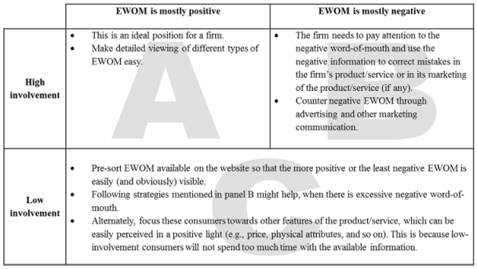

NOTE: figure/graphic rendered as an image from the PDF; its content is not machine-readable text. Caption (if any) follows as the next block.

5.1. Managerial implications

These days, it is common to see brand managers using online platforms to make their products available to consumers. Along with these online sale-points, they have also developed ways of encouraging customers to spread EWOM (Evans, 2012; Schindler and Bickart, 2005). In such cases, the valence of the EWOM generated for a product is of vital importance. This is because the valence of the different types of EWOM, in conjunction with the consumer's level of involvement, can have an impact on the consumer's idea of the brand image. As firms cannot easily regulate EWOM, there is an opportunity for negative information to spread among consumers (Samson, 2006).

Given the importance of EWOM valence, we combined the results of this study with the valence of EWOM and created a matrix (Fig. 1) that represents the possible strategies managers could use to encourage the formation of a good image of the brand from a consumer's perspective. In Fig. 1, the strategies are separated into three panels depending on the consumer's level of involvement and the valence of existing EWOM.

Panels A and B are the case of product categories in which consumers are highly involved. Based on the findings in this study, highinvolvement consumers will access more EWOM and spend more time reading the EWOM before they form some image of the brand. Therefore, it is better to design the layout of EWOM on website in such a way that the different types of EWOM information are easily accessible for detailed viewing. This would allow these highly involved consumers to get to what there are looking for (i.e., details of a particular EWOM) easily. In panel A, the valence of EWOM is generally positive, and since high-involvement consumers anyway tend to form higher expectations of the brand, there is perhaps nothing more managers can do to improve consumer's perception of the brand.

However, in panel B, the valence of EWOM is mostly negative. Although brand managers often cannot control the valence of EWOM posted on their websites, they can use the content of the EWOM to understand their product's flaws that are salient to consumers. Therefore, although brand managers cannot prevent high-involvement consumers from reading the negatively valenced EWOM thoroughly, they can still attempt to counter the negative EWOM through advertising or other marketing communication on the same online platform (and elsewhere); this is likely to raise the level of consumer expectations of the brand. Managers could also use the negative information to correct mistakes in the firm's product or in its marketing of the product.

This scenario is still better than that of panel C, because the results of this study suggest that high-involvement consumers form better perceptions of the brand than their low-involvement counterparts.

Panel C is the case of low-involvement product categories. Based on the findings in this study, low-involvement consumers will access less EWOM and spend less time reading the EWOM before they form some image of the brand. In such cases, irrespective of the valence of the EWOM, it would be advisable to pre-sort the EWOM available on the product website in such a way that the more positive or the least negative EWOM appears at the top. Since these consumers have low-involvement with the category, they tend to go through less amount of EWOM, as well as spend little time doing so. Therefore, placing the least harmful EWOM in the most accessible location might aid in the formation of a better image of the brand.

5.2. Limitations and future research

To test the hypotheses across categories, we used one item from the products category (i.e., smartphones) and one item from the services category (i.e., hotel services). Using only two categories might affect the generalizability of our findings to some extent. However, it does not necessarily affect how researchers and managers can utilize the essence of our findings in other categories. This is because most brands today have some form of online presence and, therefore, EWOM as well. Nonetheless, expanding the number of product or service categories in a replication study would be a useful extension of this research.

Furthermore, when creating our simulations, we had removed brand related information so that such information would not confounded our study of expectations. However, brand (prior) knowledge, in addition to EWOM, can also influence consumers during this information search stage (e.g., Simonson et al., 1988). Therefore, future research could consider including brand related information in order to compare its influence vis-à-vis EWOM or perhaps even in conjunction with EWOM.

EWOM's influence on consumers is growing, primarily through social media (Kohli et al., 2015). This is because EWOM has the ability to bring users of a brand together, increasing the individual's feelings of belongingness (Smith et al., 2017). Therefore, given the importance of EWOM today, and building on work done in this study, future researchers could go further by considering other consumer traits and characteristics that can moderate the influence of EWOM on consumers.

Fig. 1. Possible strategies to improve brand expectations.

A. Krishnamurthy, S.R. Kumar *Journal of Retailing and Consumer Services 43 (2018) 149–156*

154

Page 7

Appendix A. Frequency of type of EWOM on websites

| TypeofEWOM | %ofallsites | %ofsiteswithEWOMinformation | %ofsitesthatallowpurchases |
| --- | --- | --- | --- |
|  | (n=286) | (n=158) | (n=41) |
| Rankingwithnumbers(only+ve) | 30% | 54% | 85% |
| Detailedreviews | 26% | 46% | 78% |
| Numberofdetailedreviewsshown | 22% | 41% | 68% |
| Facebooklikesand/orshares | 39% | 70% | 59% |
| Reviewhaslike/dislikerating | 16% | 30% | 54% |
| Rankingwithnumbersateachrank | 11% | 20% | 41% |
| NumberofTweets | 28% | 51% | 32% |
| NumberofGoogle | 25% | 45% | 29% |
| +recommendations |  |  |  |
| Individualattributesranked | 5% | 9% | 27% |
| NumberofPinterestshares | 9% | 16% | 22% |
| Rankingwithoutnumbers(only+ve) | 3% | 5% | 7% |
| Rankingwithnumbers(both+ve | 5% | 8% | 2% |
| and -ve) |  |  |  |
| NumberofLinkedInshares | 5% | 8% | 2% |
| Number of Stumble-Upon shares | 4% | 7% | 0% |

NOTE: table converted from PDF layout to HTML text; cell boundaries are reconstructed. See PDF if exact alignment matters.

References

AdWeek, 2015. 10 Reasons Why Influencer Marketing is the Next Big Thing, Available at:

〈http://www.adweek.com/digital/10-reasons-why-influencer-marketing-is-the-nextbig-thing/〉. Bambauer-Sachse, S., Mangold, S., 2011. Brand equity dilution through negative online

word-of-mouth communication. J. Retail. Consum. Serv. 18 (1), 38–45. Becker-Olsen, K.L., Cudmore, B.A., Hill, R.P., 2006. The impact of perceived corporate

social responsibility on consumer behavior. J. Bus. Res. 59 (1), 46–53. Bloch, P.H., 1982. Involvement Beyond the Purchase Process: conceptual Issues and

Empirical Investigation. In: Mitchell, Andrew (Ed.), Advances in Consumer Research 09. Association for Consumer Research, Ann Abor, MI, pp. 413–417. Bloch, P.H., Richins, M.L., 1983. A theoretical model for the study of product importance

perceptions. J. Mark. 47 (3), 69–81. Bughin, J., Doogan, J., Vetvik, O.J., 2010. A new way to measure word-of-mouth mar-

keting, McKinsey Quarterly (April). Available at: 〈https://www.mckinsey.com/ business-functions/marketing-and-sales/our-insights/a-new-way-to-measure-wordof-mouth-marketing〉. Celsi, R.L., Olson, J.C., 1988. The role of involvement in attention and comprehension

processes. J. Consum. Res. 15 (2), 210–224. Chang, E.C., 1996. Evidence for the cultural specificity of pessimism in Asians vs

Caucasians: a test of a general negativity hypothesis. Personal. Individ. Differ. 21 (5), 819–822. Chang, E.C., Asakawa, K., Sanna, L.J., 2001. Cultural variations in optimistic and pessi-

mistic bias: do Easterners really expect the worst and Westerners really expect the best when predicting future life events? J. Personal. Social. Psychol. 81 (3), 476–491. Chen, Y., 2010. The drivers of green brand equity: green brand image, green satisfaction,

and green trust. J. Bus. Ethics 93 (2), 307–319. Chiou, J., Cheng, C., 2003. Should a company have message boards on its web sites? J.

Interact. Mark. 17 (3), 50–61. Cretu, A.E., Brodie, R.J., 2007. The influence of brand image and company reputation

where manufacturers market to small firms: a customer value perspective. Ind. Mark. Manag. 36 (2), 230–240. Datta, A., 2018. When It Comes to Putting Out Fires, Nestlé India’s Suresh Narayanan Is

No Novice, Forbes. Available at: 〈https://www.forbes.com/sites/forbesasia/2018/ 01/17/when-it-comes-to-putting-out-fires-nestle-indias-suresh-narayanan-is-nonovice/#4aa6081a7b18〉. Dawar, N., Pillutla, M.M., 2000. Impact of product-harm crises on brand equity: the

moderating role of consumer expectations. J. Mark. Res. 37 (2), 215–226. De Matos, C.A., Rossi, C.A.V., 2008. Word-of-mouth communications in marketing: a

meta-analytic review of the antecedents and moderators. J. Acad. Mark. Sci. 36 (4), 578–596. D'Hauteville, F., Fornerino, M., Philippe Perrouty, J., 2007. Disconfirmation of taste as a

measure of region of origin equity: an experimental study on five French wine regions. Int. J. Wine Bus. Res. 19 (1), 33–48. Dholakia, U.M., 2001. A motivational process model of product involvement and con-

sumer risk perception. Eur. J. Mark. 35 (11–12), 1340–1362. Dioko, L.D., Harrill, R., Cardon, P.W., 2010. Brand China: tour guide perceptions and

implications for destination branding and marketing. Tour. Anal. 15 (3), 345–355. Dobni, D., Zinkhan, G.M., 1990a. In search of brand image: a foundation analysis. In:

Goldberg, Marvin E., Gorn, Gerald, Pollay, Richard W. (Eds.), Advances in Consumer Research 17. Association for Consumer Research, Provo, UT, pp. 110–119. Dobni, D., Zinkhan, G.M., 1990a. 'In search of brand image: a foundation analysis'. Adv.

Consum. Res. 17, 110–119. Douglas, S.P., Craig, C.S., 2006. On improving the conceptual foundations of interna-

tional marketing research. J. Int. Mark. 14 (1), 1–22. Erat, S., Bhaskaran, S.R., 2012. Consumer mental accounts and implications to selling

base products and Add-ons. Mark. Sci. 31 (5), 801–818. Evans, D., 2012. Social media marketing: an hour a day. John Wiley & Sons,

Indianapolis, IA. Freling, T.H., Forbes, L.P., 2013. An empirical analysis of the brand personality effect. J.

Product. Brand Manag. 14 (7), 404–413. Gabbott, M., Hogg, G., 1999. Consumer involvement in services: a replication and ex-

tension". J. Bus. Res. 46 (2), 159–166. Gabler, C.B., Reynolds, K.E., 2013. Buy now or buy later: the effects of scarcity and

discounts on purchase decisions. J. Mark. Theory Pract. 21 (4), 441–456. Gensler, S., Völckner, F., Egger, M., Fischbach, K., Schoder, D., 2015. Listen to your

customers: insights into brand image using online consumer-generated product reviews. Int. J. Electron. Commer. 20 (1), 112–141. Ghose, A., Ipeirotis, P.G., Li, B., 2012. Designing ranking systems for hotels on travel

search engines by mining user-generated and crowdsourced content. Mark. Sci. 31 (3), 493–520. Godes, D., Mayzlin, D., 2004. Using online conversations to study word-of-mouth com-

munication. Mark. Sci. 23 (4), 545–560. Greenwald, A.G., Leavitt, C., 1984. Audience involvement in advertising: four levels. J.

Consum. Res. 11 (1), 581–592. Gupta, K., Stewart, D.W., 1996. Customer satisfaction and customer behavior: the dif-

ferential role of brand and category expectations. Mark. Lett. 7 (3), 249–263. Hair, J.F.J., Black, W.C., Babin, B.J., Anderson, R.E., Tatham, R.L., 2006. Multivariate

Data Analysis. Pearson Prentice Hall, Upper Saddle River, NJ. Haynes, A., Lackman, C., Guskey, A., 1999. Comprehensive brand presentation: ensuring

consistent brand image. J. Product. Brand Manag. 8 (4), 286–300. Herold, K., Tarkiainen, A., Sundqvist, S., 2016. How the source of word-of-mouth influ-

ences information processing in the formation of brand attitudes. J. Mark. High. Educ. 26 (1), 64–85. Högström, C., Gustafsson, A., Tronvoll, B., 2015. Strategic brand management: archetypes

for managing brands through paradoxes. J. Bus. Res. 68 (2), 391–404. Hu, J., Liu, X., Wang, S., Yang, Z., 2012. The role of brand image congruity in Chinese

consumers' brand preference. J. Product. Brand Manag. 21 (1), 26–34. Jun, S.H., Vogt, C., 2013. Travel information processing applying a dual-process model.

Ann. Tour. Res. 40, 191–212 (No. January). Karpf, D., 2012. Social science research methods in internet time. Inf., Commun. Soc. 15

(5), 639–661. Keller, K.L., 1993. Conceptualizing, measuring, and managing customer-based brand

equity. J. Mark. 57 (1), 1–22. Kohli, C., Suri, R., Kapoor, A., 2015. Will social media kill branding? Bus. Horiz. 58 (1),

35–44. Krishnamurthy, A., Kumar, S.R., 2015. Exploring the formation of consumer expectations.

J. Cust. Behav. 14 (1), 7–31. Lamons, B., 2003. 'Create focused expectations with brand image'. Mark. News 37

(20), 1–7. Langaro, D., Rita, P., de Fátima Salgueiro, M., 2015. Do social networking sites contribute

for building brands? Evaluating the impact of users' participation on brand awareness and brand attitude". J. Mark. Communications. http://dx.doi.org/10.1080/13527266. 2015.1036100. Lee, Y.T., Seligman, M.E., 1997. Are Americans more optimistic than the Chinese?

Personal. Social. Psychol. Bull. 23 (1), 32–40.

A. Krishnamurthy, S.R. Kumar *Journal of Retailing and Consumer Services 43 (2018) 149–156*

155

Page 8

Litvin, S.W., Goldsmith, R.E., Pan, B., 2008. Electronic word-of-mouth in hospitality and

tourism management. Tour. Manag. 29 (3), 458–468. Loewenstein, J., Raghunathan, R., Heath, C., 2011. The repetition-break plot structure

makes effective television advertisements. J. Mark. 75 (5), 105–119. MacKenzie, S.B., Spreng, R.A., 1992. How does motivation moderate the impact of central

and peripheral processing on brand attitudes and intentions? J. Consum. Res. 18 (4), 519–529. Maclnnis, D.J., Jaworski, B.J., 1989. Information processing from advertisements: toward

an integrative framework. J. Mark. 53 (4), 1–23. Marsden, P., Samson, A., Upton, N., 2005. Advocacy drives growth. Brand Strategy (198),

45–47. Meenaghan, T., 1995. The role of advertising in brand image development. J. Product.

Brand Manag. 4 (4), 23–34. Mishra, A., Maheswarappa, S.S., Maity, M., Samu, S., 2017. Adolescent's eWOM inten-

tions: an investigation into the roles of peers, the Internet and gender (in press). J. Bus. Res. Mittal, B., Lee, M., 1989. A causal model of consumer involvement. J. Econ. Psychol. 10

(3), 363–389. Myers, B., Kwon, W., Forsythe, S., 2013. Creating successful cause–brand alliances: the

role of cause involvement, perceived brand motivations and cause–brand alliance attitude. J. Brand Manag. 20 (3), 205–217. Nunnally, J.C., 1978. Psychometric Theory. McGraw-Hill, New York. Oliver, R.L., 1980. A cognitive model of the antecedents and consequences of satisfaction

decisions. J. Mark. Res. 17 (4), 460–469. Oliver, R.L., 2011. Satisfaction: a behavioral perspective on the consumer. M. E. Sharpe,

Chennai, India. Olson, J.C., Dover, P.A., 1979. Disconfirmation of consumer expectations through product

trial. J. Appl. Psychol. 64 (2), 179–189. Park, C.W., Young, S.M., 1986. Consumer response to television commercials: the impact

of involvement and background music on brand attitude formation. J. Mark. Res. 23 (1), 11–24. Park, C.W., Jaworski, B.J., Maclnnis, D.J., 1986. Strategic brand concept-image man-

agement. J. Mark. 50 (4), 135–145. Petty, R.E., Cacioppo, J.T., 1981. Attitudes and persuasion: classic and contemporary

approaches. William C. Brown, Dubuque, IA. Petty, R.E., Cacioppo, J.T., 1984. The effects of involvement on responses to argument

quantity and quality: central and peripheral routes to persuasion. J. Personal. Social. Psychol. 46 (1), 69–81. Petty, R.E., Cacioppo, J.T., Schumann, D., 1983. Central and peripheral routes to ad-

vertising effectiveness: the moderating role of involvement. J. Consum. Res. 10 (2), 135–146. Plotkina, D., Munzel, A., 2016. Delight the experts, but never dissatisfy your customers! A

multi-category study on the effects of online review source on intention to buy a new product. J. Retail. Consum. Serv. 29, 1–11. Prakash, V., 1984. Validity and reliability of the confirmation of expectations paradigm as

a determinant of consumer satisfaction. J. Acad. Mark. Sci. 12 (4), 63–76. Reichelt, J., Sievert, J., Jacob, F., 2014. How credibility affects eWOM reading: the in-

fluences of expertise, trustworthiness, and similarity on utilitarian and social functions. J. Mark. Commun. 20 (1–2), 65–81. Reza Jalilvand, M., Samiei, N., 2012. The effect of electronic word of mouth on brand

image and purchase intention: an empirical study in the automobile industry in Iran. Mark. Intell. Plan. 30 (4), 460–476.

Riegner, C., 2007. Word of mouth on the web: the impact of Web 2.0 on consumer

purchase decisions. J. Advert. Res. 47 (4), 436–447. Rodrigues, C., Krishnamurthy, A., 2016. Mirror, mirror on the wall: identity-image

Interactions for the sales force in high threat situations. Eur. Manag. Rev. 13 (4), 307–323. Roy, D., Banerjee, S., 2014. Identification and measurement of brand identity and image

gap: a quantitative approach. J. Product. Brand Manag. 23 (3), 207–219. Samson, A., 2006. Understanding the buzz that matters: negative vs positive word of

mouth. Int. J. Mark. Res. 48 (6), 647–657. Schindler, R.M., Bickart, B., 2005. Published word of mouth: referable, consumer-gen-

erated information on the Internet. In: Haugtvedt, C.P., Machleit, K.A., Yalch, R. (Eds.), Online consumer psychology: Understanding and influencing consumer behavior in the virtual world. Lawrence Erlbaum Associates, New York, pp. 32–58. Schmidt, J.B., Spreng, R.A., 1996. A proposed model of external consumer information

search. J. Acad. Mark. Sci. 24 (3), 246–256. Simonson, I., Huber, J., Payne, J., 1988. The relationship between prior brand knowledge

and information acquisition order. J. Consum. Res. 14 (4), 566–578. Sirakaya-Turk, E., Ekinci, Y., Martin, D., 2015. The efficacy of shopping value in pre-

dicting destination loyalty. J. Bus. Res. 68 (9), 1878–1885. Smith, A.C., Stavros, C., Westberg, K., 2017. Brand Fans: lessons from the World's Greatest

Sporting Brands. Palgrave Macmillan. Steenkamp, J.E., Baumgartner, H., 1998. Assessing measurement invariance in cross-

national consumer research. J. Consum. Res. 25 (1), 78–90. Sultana, N., 2017. How the Power of Individual Voice Online Destroys a Brand, BrandBa.

Available at: 〈http://www.brandba.se/blog/how-the-power-of-individual-voicesonline-destroys-a-brand〉. Swan, J.E., Trawick, I.F., Carroll, M.G., 1980. Satisfaction related to predictive, desired

expectations: a field study. In: Hunt, J.K., Day, R.L. (Eds.), Refining Concepts and Measures of Consumer Satisfaction and Complaining Behavior. Indiana University Press, Bloomington, IN, pp. 7–12. Thakur, R., 2018. Customer engagement and online reviews. J. Retail. Consum. Serv. 41,

48–59 (No.)(March). Tyron, W.W., 1994. Expectation. In: Ramachandran, V.S. (Ed.), Encyclopedia of Human

Behavior. Academic Press, San Diego, CA, pp. 313–319. Urbany, J.E., Dickson, P.R., Wilkie, W.L., 1989. Buyer Uncertainty and Information

Search. J. Consum. Res. 16 (2), 208–215. Van Raaij, W.F., 1998. The Formation and Use of Expectations in Consumer Decision

Making. In: Robertson, T.S., Kassarjian, H.H. (Eds.), Handbook of Consumer Behavior. Prentice Hall, Upper Saddle River, NJ, pp. 401–418. Werther, W.B., Chandler, D., 2005. Strategic corporate social responsibility as global

brand insurance. Bus. Horiz. 48 (4), 317–324. Westbrook, R.A., 1987. Product/ consumption-based affective responses and post-pur-

chase rocesses. J. Mark. Res. 24 (3), 258–270. Wu, P.C., Wang, Y., 2011. The influences of electronic word-of-mouth message appeal

and message source credibility on brand attitude. Asia Pac. J. Mark. Logist. 23 (4), 448–472. Xun, J., Guo, B., 2017. Twitter as customer's eWOM: an empirical study on their impact

on firm financial performance. Internet Res. 27 (5), 1014–1038. Zaichkowsky, J.L., 1985. Measuring the involvement construct. J. Consum. Res. 12 (3),

341–352. Zaichkowsky, J.L., 1994. The personal involvement inventory: reduction, revision, and

application to advertising. J. Advert. 23 (4), 59–70.

A. Krishnamurthy, S.R. Kumar *Journal of Retailing and Consumer Services 43 (2018) 149–156*

156